# Sentiment Analysis of McDonald’s Customer Reviews

Awad Pervez

15 December 2025

# Project Overview

This project explores customer sentiment in McDonald’s reviews using lexicon-based natural language processing techniques. Three sentiment lexicons Bing, AFINN, and NRC are applied to analyse sentiment polarity, intensity, and emotional content. The analysis demonstrates how different lexicons provide complementary insights into customer feedback.

## 1. LOAD DATA

```r
file_path <- "Z:\\Data Science MSc\\Data_Mining\\week 02\\mcdonalds_sentiment_project\\data\\McDonald_s_Reviews.csv"

mcd <- read.csv(file_path, stringsAsFactors = FALSE) %>% as_tibble()

glimpse(mcd)
```

```
## Rows: 33,396
## Columns: 10
## $ reviewer_id   <int> 1, 2, 3, 4, 5, 6, 7, 8, 9, 10, 11, 12, 13, 14, 15, 16, 1…
## $ store_name    <chr> "McDonald's", "McDonald's", "McDonald's", "McDonald's", …
## $ category      <chr> "Fast food restaurant", "Fast food restaurant", "Fast fo…
## $ store_address <chr> "13749 US-183 Hwy, Austin, TX 78750, United States", "13…
## $ latitude      <dbl> 30.46072, 30.46072, 30.46072, 30.46072, 30.46072, 30.460…
## $ longitude     <dbl> -97.79287, -97.79287, -97.79287, -97.79287, -97.79287, -…
## $ rating_count  <chr> "1,240", "1,240", "1,240", "1,240", "1,240", "1,240", "1…
## $ review_time   <chr> "3 months ago", "5 days ago", "5 days ago", "a month ago…
## $ review        <chr> "Why does it look like someone spit on my food?\nI had a…
## $ rating        <chr> "1 star", "4 stars", "1 star", "5 stars", "1 star", "1 s…
```

```r
summary(mcd)
```

```
##   reviewer_id     store_name          category         store_address
##  Min.   :    1   Length:33396       Length:33396       Length:33396
##  1st Qu.: 8350   Class :character   Class :character   Class :character
##  Median :16699   Mode  :character   Mode  :character   Mode  :character
##  Mean   :16699
##  3rd Qu.:25047
##  Max.   :33396
##
##     latitude       longitude       rating_count       review_time
##  Min.   :25.79   Min.   :-122.00   Length:33396       Length:33396
##  1st Qu.:28.66   1st Qu.: -97.79   Class :character   Class :character
##  Median :33.93   Median : -81.47   Mode  :character   Mode  :character
##  Mean   :34.44   Mean   : -90.65
##  3rd Qu.:40.73   3rd Qu.: -75.40
##  Max.   :44.98   Max.   : -73.46
##  NA's   :660     NA's   :660
##     review             rating
##  Length:33396       Length:33396
##  Class :character   Class :character
##  Mode  :character   Mode  :character
##
##
##
##
```

```r
head(mcd$review, 5)
```

```
## [1] "Why does it look like someone spit on my food?\nI had a normal transaction,  everyone was chill and polite, but now i dont want to eat this. Im trying not to think about what this milky white/clear substance is all over my food, i d*** sure am not coming back."
## [2] "It'd McDonalds. It is what it is as far as the food and atmosphere go. The staff here does make a difference. They are all friendly, accommodating and always smiling. Makes for a more pleasant experience than many other fast food places."
## [3] "Made a mobile order got to the speaker and checked it in.\nLine was not moving so I had to leave otherwise I���������������������������d be late for work.\nNever got the refund in the app.\nI called them and they said I could only get my money back in person because it was stuck in the syste…
## [4] "My mc. Crispy chicken sandwich was ������������������������������������ customer service was quick and p"
## [5] "I repeat my order 3 times in the drive thru, and she still manage to mess it up , it was suppose to be a large meal double filet of fish with large fries , no cheese . It was all wrong , they either need to pay close attention to the order being made , understand English or they need not to …
```

## 2. Sample reviews

```r
# Keeping only useful columns for sentiment analysis
mcd_selected <- mcd %>%
  select(
    reviewer_id,
    store_name,
    category,
    review,
    rating,
    review_time
  ) %>%
  filter(!is.na(review), review != "")     #   Remove empty reviews

# Set seed for reproducibility
set.seed(123)

# Choose sample size
sample_size <- 500

if (nrow(mcd_selected) > sample_size) {
  mcd_sample <- mcd_selected %>%
    slice_sample(n = sample_size) %>%
    mutate(review_id = row_number())
} else {
  mcd_sample <- mcd_selected %>%
    mutate(review_id = row_number())
}

nrow(mcd_sample)
```

```
## [1] 500
```

```r
head(mcd_sample$review, 3)
```

```
## [1] "Food was bad. They barely put special sauce on Big Mac. I couldn't really taste the sauce at all."
## [2] "Could only order from kiosk. Wanted some extras but serving staff struggled with English"
## [3] "Excellent "
```

## 3. Tokenise and clean

```r
# Tokenize reviews into individual words
mcd_tokens <- mcd_sample %>%
  unnest_tokens(
    output = word,      # column that will store each token
    input  = review,    # text column
    token  = "words",   # split into words
    to_lower = TRUE     # convert to lowercase
  )

glimpse(mcd_tokens)
```

```
## Rows: 10,751
## Columns: 7
## $ reviewer_id <int> 2986, 2986, 2986, 2986, 2986, 2986, 2986, 2986, 2986, 2986…
## $ store_name  <chr> "McDonald's", "McDonald's", "McDonald's", "McDonald's", "M…
## $ category    <chr> "Fast food restaurant", "Fast food restaurant", "Fast food…
## $ rating      <chr> "1 star", "1 star", "1 star", "1 star", "1 star", "1 star"…
## $ review_time <chr> "2 months ago", "2 months ago", "2 months ago", "2 months …
## $ review_id   <int> 1, 1, 1, 1, 1, 1, 1, 1, 1, 1, 1, 1, 1, 1, 1, 1, 1, 1, 1, 2…
## $ word        <chr> "food", "was", "bad", "they", "barely", "put", "special", …
```

```r
head(mcd_tokens$word, 20)
```

```
##  [1] "food"     "was"      "bad"      "they"     "barely"   "put"
##  [7] "special"  "sauce"    "on"       "big"      "mac"      "i"
## [13] "couldn't" "really"   "taste"    "the"      "sauce"    "at"
## [19] "all"      "could"
```

```r
nrow(mcd_tokens)
```

```
## [1] 10751
```

```r
mcd_clean <- mcd_tokens %>%
  anti_join(stop_words, by = "word") %>%          # remove stop words
  mutate(word = gsub("[^a-zA-Z]", "", word)) %>%  # remove non-letters
  filter(word != "")                              # remove empty tokens
```

```r
nrow(mcd_tokens)     #  Total words BEFORE cleaning (after tokenization)
```

```
## [1] 10751
```

```r
nrow(mcd_clean)      # Total words AFTER cleaning (stop words + non-letters removed).
```

```
## [1] 3763
```

```r
# 10751 − 3763 = 6988 words removed
```

```r
# Stop words like the, and, is, to are very frequent but useless for sentiment.

# Cleaning removes punctuation leftovers and junk tokens.

# Lexicons work better on this reduced, meaningful vocabulary.

# If we had removed only 10%, cleaning would be too weak.
# If we removed 95%, cleaning would be too aggressive.
# ~60–70% removal is right where you want to be.
```

## 4. Bing sentiment

```r
# Load the Bing lexicon

bing <- get_sentiments("bing")

head(bing)
```

```
## # A tibble: 6 × 2
##   word       sentiment
##   <chr>      <chr>
## 1 2-faces    negative
## 2 abnormal   negative
## 3 abolish    negative
## 4 abominable negative
## 5 abominably negative
## 6 abominate  negative
```

Here i will appply bing Lexicon to my cleaned tokens

```r
mcd_bing <- mcd_clean %>%
  inner_join(bing, by = "word")
```

```r
table(mcd_bing$sentiment)
```

```
##
## negative positive
##      370      392
```

```r
head(mcd_bing, 10)
```

```
## # A tibble: 10 × 8
##    reviewer_id store_name category  rating review_time review_id word  sentiment
##          <int> <chr>      <chr>     <chr>  <chr>           <int> <chr> <chr>
##  1        2986 McDonald's Fast foo… 1 star 2 months a…         1 bad   negative
##  2       29925 McDonald's Fast foo… 2 sta… 2 months a…         2 stru… negative
##  3       29710 McDonald's Fast foo… 5 sta… 2 years ago         3 exce… positive
##  4       31313 McDonald's Fast foo… 2 sta… 5 years ago         6 shoc… negative
##  5       31313 McDonald's Fast foo… 2 sta… 5 years ago         6 nice  positive
##  6       31313 McDonald's Fast foo… 2 sta… 5 years ago         6 stro… positive
##  7       27168 McDonald's Fast foo… 3 sta… 5 years ago         9 fast  positive
##  8       24173 McDonald's Fast foo… 2 sta… 6 months a…        10 frus… negative
##  9       24173 McDonald's Fast foo… 2 sta… 6 months a…        10 adeq… positive
## 10       24173 McDonald's Fast foo… 2 sta… 6 months a…        10 lack  negative
```

Summarise sentiment per review

```r
# Counts positive words per review

# Counts negative words per review

# Computes final sentiment score






mcd_bing_scores <- mcd_bing %>%
  group_by(review_id) %>%
  summarise(
    positive = sum(sentiment == "positive"),
    negative = sum(sentiment == "negative"),
    bing_score = positive - negative
  ) %>%
  ungroup()
```

```r
# Inspect first few sentiment scores
head(mcd_bing_scores, 10)
```

```
## # A tibble: 10 × 4
##    review_id positive negative bing_score
##        <int>    <int>    <int>      <int>
##  1         1        0        1         -1
##  2         2        0        1         -1
##  3         3        1        0          1
##  4         6        2        1          1
##  5         9        1        0          1
##  6        10        1        2         -1
##  7        12        0        1         -1
##  8        13        0        2         -2
##  9        14        1        2         -1
## 10        15        1        0          1
```

```r
# Overall distribution of sentiment scores
summary(mcd_bing_scores$bing_score)
```

```
##     Min.  1st Qu.   Median     Mean  3rd Qu.     Max.
## -7.00000 -1.00000  1.00000  0.06509  1.00000  6.00000
```

# DISTRIBUTION OF BING SENTIMENT SCORES (Histogram)

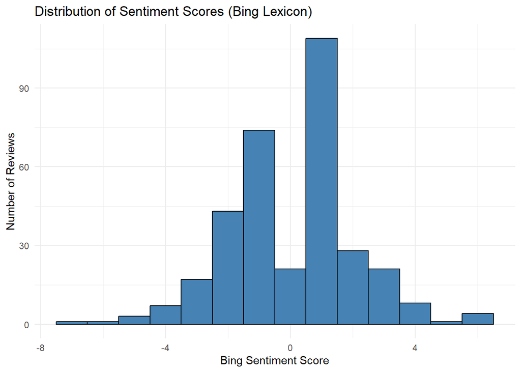

```r
library(ggplot2)

ggplot(mcd_bing_scores, aes(x = bing_score)) +
  geom_histogram(binwidth = 1, fill = "steelblue", color = "black") +
  labs(
    title = "Distribution of Sentiment Scores (Bing Lexicon)",
    x = "Bing Sentiment Score",
    y = "Number of Reviews"
  ) +
  theme_minimal()
```

**Summary:**  
The distribution shows that the most frequent Bing sentiment score is +1 (109 reviews), indicating that customer feedback is generally mildly positive. Mild negative sentiment (−1) is also common, suggesting frequent minor complaints. Neutral sentiment is less common, while extreme positive and negative scores occur rarely, showing that most reviews express mild rather than strong emotion.

# # Positive vs Negative Word Counts (Bar Chart)

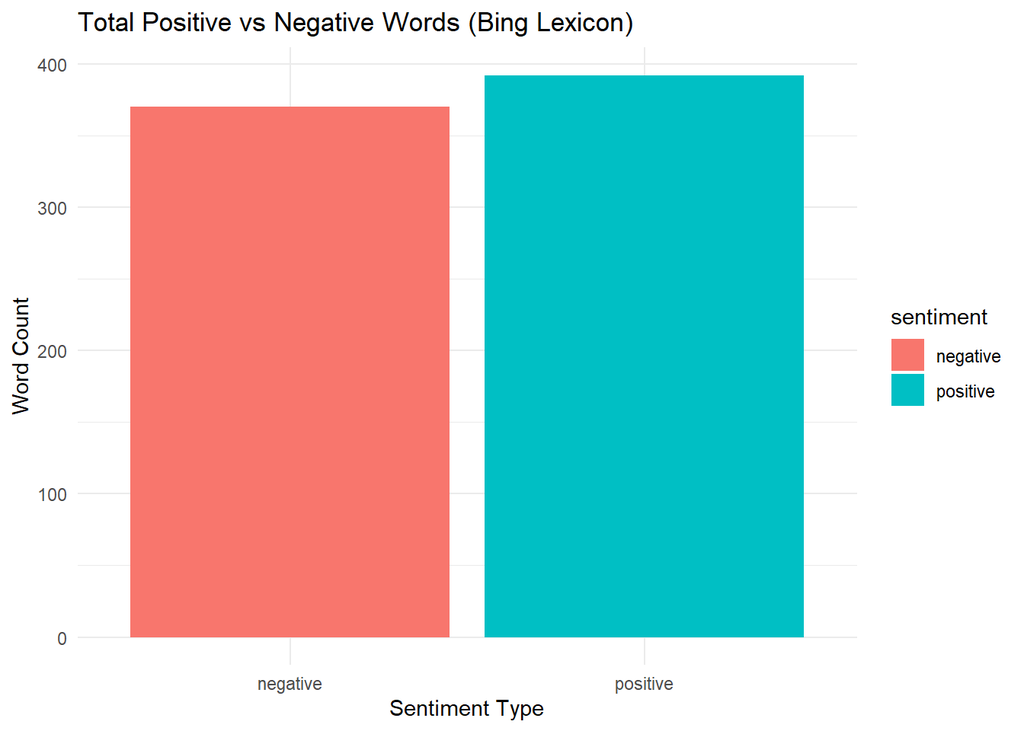

```r
mcd_bing %>%
  count(sentiment) %>%
  ggplot(aes(x = sentiment, y = n, fill = sentiment)) +
  geom_col() +
  labs(
    title = "Total Positive vs Negative Words (Bing Lexicon)",
    x = "Sentiment Type",
    y = "Word Count"
  ) +
  theme_minimal()
```

# Sentiment Score vs Star Rating (Boxplot)

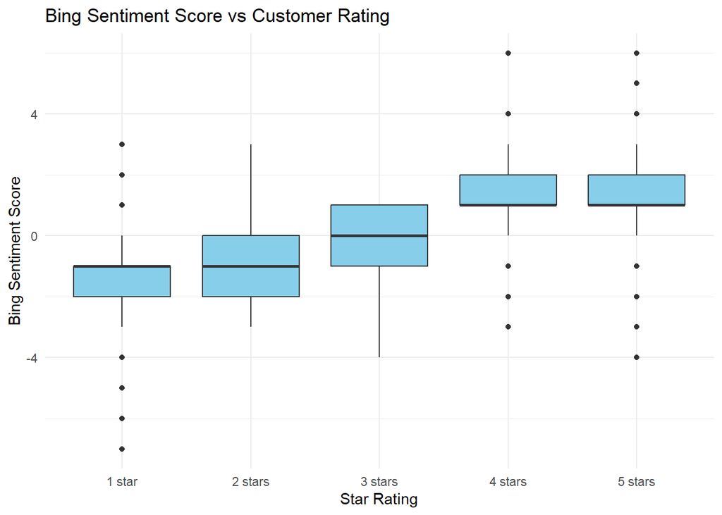

```r
mcd_bing_scores %>%
  left_join(mcd_sample, by = "review_id") %>%
  ggplot(aes(x = factor(rating), y = bing_score)) +
  geom_boxplot(fill = "skyblue") +
  labs(
    title = "Bing Sentiment Score vs Customer Rating",
    x = "Star Rating",
    y = "Bing Sentiment Score"
  ) +
  theme_minimal()
```

**Summary:**  
The boxplot shows a clear positive relationship between star ratings and Bing sentiment scores. Lower-rated reviews (1–2 stars) have predominantly negative sentiment, while higher-rated reviews (4–5 stars) show positive median sentiment scores. Reviews with mid-range ratings (3 stars) exhibit mixed sentiment, indicating balanced positive and negative language. Overall, the results suggest that textual sentiment aligns well with customer star ratings.

## 5. AFINN sentiment

```r
# Load AFINN lexicon

afinn <- get_sentiments("afinn")
head(afinn)
```

```
## # A tibble: 6 × 2
##   word       value
##   <chr>      <dbl>
## 1 abandon       -2
## 2 abandoned     -2
## 3 abandons      -2
## 4 abducted      -2
## 5 abduction     -2
## 6 abductions    -2
```

```r
# Apply AFINN to tokens
mcd_afinn <- mcd_clean %>%
  inner_join(afinn, by = "word")     #  Keeps only words that exist in the AFINN lexicon


summary(mcd_afinn$value)
```

```
##    Min. 1st Qu.  Median    Mean 3rd Qu.    Max.
## -5.0000 -2.0000  1.0000  0.2193  2.0000  5.0000
```

First, the review text is tokenised and cleaned. Each word is then matched against the AFINN lexicon, which assigns a numeric sentiment value to sentiment-bearing words. The summary shows the distribution of these word-level sentiment scores across the dataset.

#Compute “Review level” AFFIN SCORE

```r
mcd_afinn_scores <- mcd_afinn %>%
  group_by(review_id) %>%
  summarise(
    afinn_score = sum(value)
  ) %>%
  ungroup()
```

```r
head(mcd_afinn_scores)
```

```
## # A tibble: 6 × 2
##   review_id afinn_score
##       <int>       <dbl>
## 1         1          -3
## 2         2          -2
## 3         3           3
## 4         6           3
## 5         7          -4
## 6        10          -3
```

```r
summary(mcd_afinn_scores$afinn_score)
```

```
##     Min.  1st Qu.   Median     Mean  3rd Qu.     Max.
## -12.0000  -2.0000   1.0000   0.4223   3.0000  15.0000
```

**Summary:**

At the **review level**, AFINN sentiment scores range from −12 to +15, indicating the presence of both strongly negative and strongly positive reviews. The median score of +1 and mean score of approximately +0.42 suggest that overall customer sentiment is slightly positive. The interquartile range from −2 to +3 shows that the middle 50% of reviews express mild sentiment rather than extreme opinions.

# AFINN Sentiment Score Histogram:

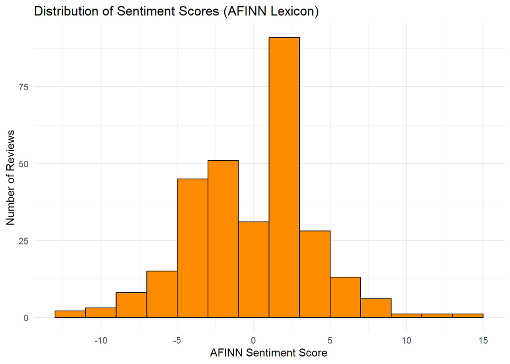

```r
ggplot(mcd_afinn_scores, aes(x = afinn_score)) +
  geom_histogram(
    binwidth = 2,
    fill = "darkorange",
    color = "black"
  ) +
  labs(
    title = "Distribution of Sentiment Scores (AFINN Lexicon)",
    x = "AFINN Sentiment Score",
    y = "Number of Reviews"
  ) +
  theme_minimal()
```

**Summary:**  
At the review level, AFINN sentiment scores are concentrated around small positive and negative values, with most reviews clustered near zero. The distribution shows a slight positive bias, consistent with the median score of +1 and mean of approximately +0.42. Compared to Bing, the wider range of scores reflects AFINN’s ability to capture sentiment intensity, while extreme positive and negative reviews remain relatively rare.

## 6. NRC emotions lexicon

```r
nrc <- get_sentiments("nrc")
head(nrc)
```

```
## # A tibble: 6 × 2
##   word      sentiment
##   <chr>     <chr>
## 1 abacus    trust
## 2 abandon   fear
## 3 abandon   negative
## 4 abandon   sadness
## 5 abandoned anger
## 6 abandoned fear
```

# Joining NRC with cleaned tokens

```r
mcd_nrc <- mcd_clean %>%
  inner_join(nrc, by = "word")
```

```r
head(mcd_nrc)
```

```
## # A tibble: 6 × 8
##   reviewer_id store_name category   rating review_time review_id word  sentiment
##         <int> <chr>      <chr>      <chr>  <chr>           <int> <chr> <chr>
## 1        2986 McDonald's Fast food… 1 star 2 months a…         1 food  joy
## 2        2986 McDonald's Fast food… 1 star 2 months a…         1 food  positive
## 3        2986 McDonald's Fast food… 1 star 2 months a…         1 food  trust
## 4        2986 McDonald's Fast food… 1 star 2 months a…         1 bad   anger
## 5        2986 McDonald's Fast food… 1 star 2 months a…         1 bad   disgust
## 6        2986 McDonald's Fast food… 1 star 2 months a…         1 bad   fear
```

# Counting emotions across the dataset

```r
nrc_counts <- mcd_nrc %>%
  count(sentiment, sort = TRUE)

nrc_counts
```

```
## # A tibble: 10 × 2
##    sentiment        n
##    <chr>        <int>
##  1 positive       553
##  2 trust          395
##  3 joy            332
##  4 negative       328
##  5 anticipation   243
##  6 anger          160
##  7 fear           144
##  8 disgust        137
##  9 sadness        132
## 10 surprise        65
```

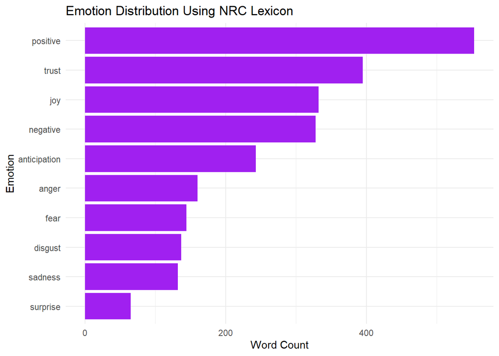

```r
ggplot(nrc_counts, aes(x = reorder(sentiment, n), y = n)) +
  geom_col(fill = "purple") +
  coord_flip() +
  labs(
    title = "Emotion Distribution Using NRC Lexicon",
    x = "Emotion",
    y = "Word Count"
  ) +
  theme_minimal()
```

**Conclusion (NRC Lexicon):**  
The NRC emotion analysis reveals that customer reviews contain a diverse range of emotional expressions. Positive-related emotions such as *positive*, *trust*, and *joy* appear most frequently, indicating generally favourable customer engagement with McDonald’s. However, negative emotions including *anger*, *fear*, *disgust*, and *sadness* are also present, reflecting dissatisfaction in a subset of reviews. Compared to Bing and AFINN, which focus on sentiment polarity and intensity, the NRC lexicon provides a richer emotional perspective by highlighting the specific emotions underlying customer feedback. Together, the results suggest that while overall sentiment is slightly positive, customer experiences are emotionally varied.

## 7. Overall conclusion

This project applied lexicon-based sentiment analysis to McDonald’s customer reviews using three different approaches: Bing, AFINN, and NRC. Each lexicon provided a distinct perspective on customer feedback. The Bing lexicon captured sentiment polarity and showed that reviews tend to be slightly positive overall. The AFINN lexicon extended this analysis by incorporating sentiment intensity, revealing a wider range of review-level sentiment scores while still indicating a mild positive bias across the dataset. The NRC lexicon further enriched the analysis by identifying the emotional composition of reviews, highlighting frequent expressions of trust, joy, and anticipation alongside the presence of negative emotions such as anger and sadness.

Across all three methods, the results were broadly consistent, suggesting that customer sentiment toward McDonald’s is generally mildly positive, with most reviews expressing moderate rather than extreme opinions. However, the NRC analysis demonstrated that customer experiences are emotionally diverse, even when overall sentiment appears positive. Together, these findings show that combining multiple lexicons provides a more comprehensive understanding of customer feedback, capturing sentiment direction, intensity, and underlying emotional context.